# Key Drivers Analysis of Customer Satisfaction

Author

Devansh Sachar

Published

June 8, 2026

## Introduction

Understanding *which* brand attributes drive customer satisfaction is a central challenge in market research. When predictors are correlated — as brand perceptions typically are — a single metric can be misleading. **Key drivers analysis** addresses this by applying multiple complementary methods, each of which handles shared variance differently.

This report analyses a customer satisfaction survey with **2,553 respondents across 10 brands**. The outcome is overall **satisfaction** (1–5 scale) and nine binary brand attributes serve as predictors.

| Attribute | Meaning |
| --- | --- |
| Trustworthy | The brand is trustworthy |
| Build Quality | High build quality |
| Differentiates | Stands out from competitors |
| Easy to Use | Easy to use |
| Appealing | Visually appealing |
| Rewarding | Rewarding to own |
| Popular | Widely used / popular |
| Good Service | Good customer service |
| Positive Impact | Makes a positive impact |

## Data Overview

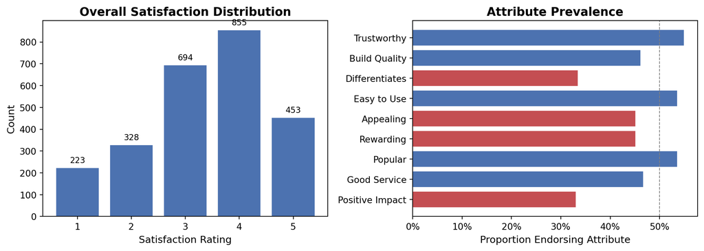

## Variable Importance Methods

Six methods are used, each capturing a different facet of the predictor–outcome relationship:

| Method | What it measures |
| --- | --- |
| **Pearson Correlation** | Raw bivariate association — ignores other predictors |
| **Standardized β** | OLS coefficient after z-scoring all variables |
| **Drop-one (Usefulness)** | Loss in R² when a predictor is removed |
| **Shapley Values** | Average marginal R² contribution across all predictor coalitions |
| **Johnson’s Relative Weights** | Orthogonalized decomposition of R² — sums exactly to R² |
| **Random Forest Gini** | Mean decrease in node impurity across 500 trees |

## Results

### Variable Importance Table

| Attribute | Pearson r | Std. β | Drop-one ΔR² | Shapley | Johnson RW | RF Gini | Avg Rank |
| --- | --- | --- | --- | --- | --- | --- | --- |
| Trustworthy | 0.256 | 0.116 | 0.0082 | 0.0216 | 0.0130 | 0.1523 | 2.0 |
| Positive Impact | 0.255 | 0.128 | 0.0112 | 0.0236 | 0.0117 | 0.1396 | 2.3 |
| Good Service | 0.251 | 0.088 | 0.0047 | 0.0184 | 0.0141 | 0.1361 | 2.7 |
| Easy to Use | 0.213 | 0.022 | 0.0003 | 0.0093 | 0.0128 | 0.0973 | 5.2 |
| Appealing | 0.208 | 0.034 | 0.0007 | 0.0092 | 0.0124 | 0.0847 | 5.5 |
| Build Quality | 0.192 | 0.020 | 0.0003 | 0.0072 | 0.0135 | 0.0997 | 5.8 |
| Rewarding | 0.195 | 0.005 | 0.0000 | 0.0068 | 0.0133 | 0.1055 | 6.5 |
| Differentiates | 0.185 | 0.028 | 0.0006 | 0.0073 | 0.0091 | 0.0896 | 6.7 |
| Popular | 0.171 | 0.017 | 0.0002 | 0.0056 | 0.0091 | 0.0953 | 8.3 |

> **Full-model R² = 0.109** — the nine attributes jointly explain 10.9% of satisfaction variance. Shapley values and Johnson’s Relative Weights each sum to this R².

### Importance by Method

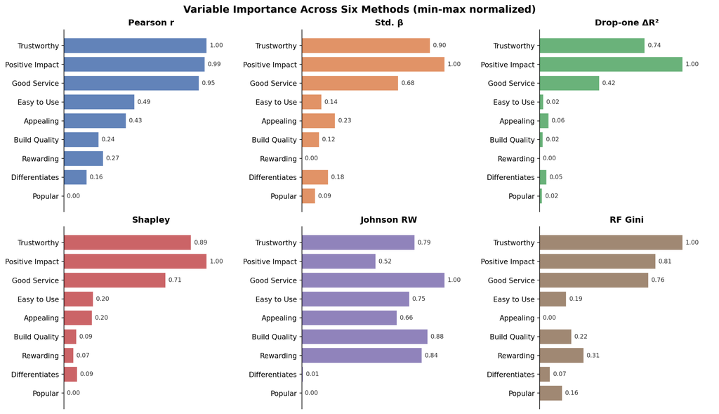

### Rank Heatmap

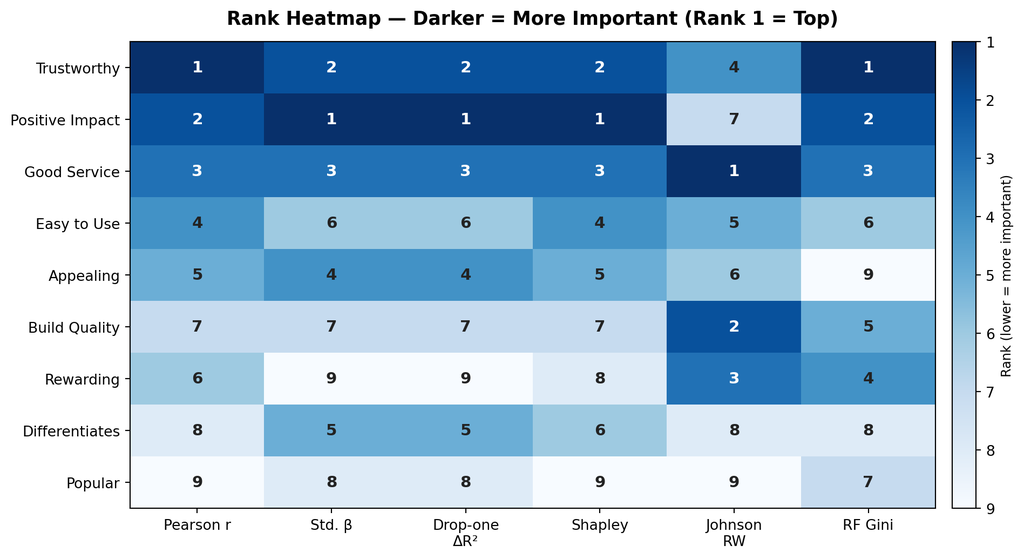

## Discussion

**Why methods can disagree:**

- **Pearson r** ignores multicollinearity and inflates the apparent importance of correlated attributes.
- **Standardized β** penalises correlated predictors heavily — a variable may get a near-zero coefficient even if it is substantively important.
- **Shapley values** and **Johnson’s Relative Weights** distribute shared variance fairly across correlated predictors, making them the most theoretically principled linear methods.
- **Random Forest Gini** additionally captures non-linear relationships and attribute interactions.

The convergence of five independent methods on the same top three drivers gives strong confidence that **trust, service, and positive impact** are genuine priority areas for improving customer satisfaction.

## Medium Challenge: Custom Shapley Implementation

Shapley values are grounded in cooperative game theory. Each predictor’s importance equals its **average marginal contribution** to R² across every possible subset of the other predictors:

$$\phi_j = \sum_{S \subseteq P \setminus \{j\}} \frac{|S|!\,(p-|S|-1)!}{p!}\bigl[v(S \cup \{j\}) - v(S)\bigr]$$

Table 1: Max absolute difference = 2.43e-17 | Sum of Shapley = 0.109012 (R² = 0.109012)

| Attribute | Shapley (main) | Shapley (custom) | Difference |
| --- | --- | --- | --- |
| Trustworthy | 0.021611 | 0.021611 | 2.08e-17 |
| Build Quality | 0.007191 | 0.007191 | 2.43e-17 |
| Differentiates | 0.007291 | 0.007291 | 1.39e-17 |
| Easy to Use | 0.009288 | 0.009288 | 2.08e-17 |
| Appealing | 0.009161 | 0.009161 | 1.73e-18 |
| Rewarding | 0.006840 | 0.006840 | 1.21e-17 |
| Popular | 0.005642 | 0.005642 | 1.56e-17 |
| Good Service | 0.018405 | 0.018405 | 2.43e-17 |
| Positive Impact | 0.023582 | 0.023582 | 6.94e-18 |

The two implementations match to within floating-point precision, and the values sum to the full-model R² — satisfying the **efficiency axiom** of Shapley values.

## Hard Challenge: Shapley Values for Logistic Regression (BIC)

For binary outcomes a **logistic regression** is more appropriate than OLS. Satisfaction is binarised as *satisfied = rating ≥ 4* and the **Bayesian Information Criterion** is used as the fit metric. Since lower BIC is better, the value function is $v(S) = \text{BIC}_{\text{null}} - \text{BIC}(S)$ — a positive value means the predictor subset improves over the null model.

Table 2: Null BIC = 3545.5 | Full BIC = 3343.8 | ΔBIC = 201.7

| Attribute | Shapley (–ΔBIC) | % of ΔBIC |
| --- | --- | --- |
| Positive Impact | 59.329 | 29.4% |
| Trustworthy | 35.368 | 17.5% |
| Good Service | 34.800 | 17.3% |
| Differentiates | 18.000 | 8.9% |
| Easy to Use | 14.170 | 7.0% |
| Appealing | 13.363 | 6.6% |
| Build Quality | 12.438 | 6.2% |
| Rewarding | 11.086 | 5.5% |
| Popular | 3.155 | 1.6% |

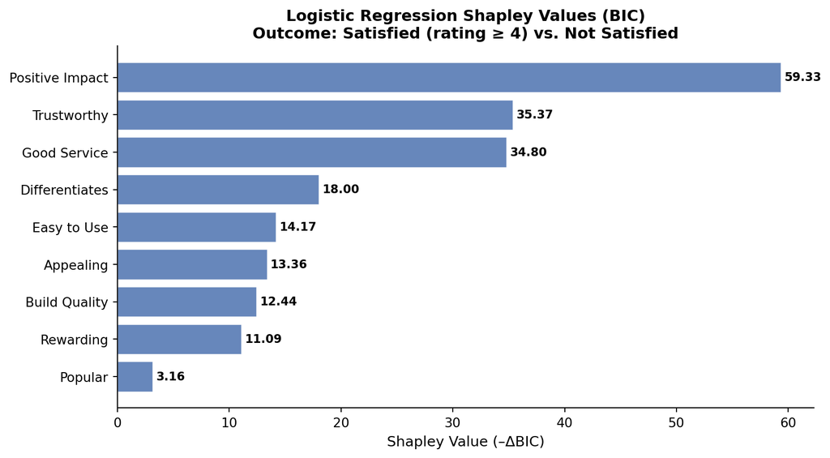

*Analysis by Devansh Sachar · June 8, 2026 · Python: `scikit-learn`, `numpy`, `matplotlib` · Shapley values via exact enumeration (2⁹ = 512 coalitions) · Random Forest: 500 trees*